# EDA

Nora Lee Reinhardt and May Norman

2025-11-07

This datafile is about the success of math students based on a set of input variables. The binary predictors are school, sex, address, famsize, Pstatus, schoolsup, famsup, paid, activities, nursery, higher, internet, romantic. The categorical predictors are Medu, Fedu, Mjob, Fjob, reason, guardian, traveltime, studytime. The numeric variables are failures, absences. The target variable is G4 which is a categorical variable to indicate a student’s success. There are 31 predictors and 273 values of each. There are no NAs.

```r
library(tidyverse)
mathscores <- read.csv("MathScores.csv")

view(head(mathscores))
```

```r
summary(mathscores)
```

```
##        ID           school              sex                 age
##  Min.   :102.0   Length:273         Length:273         Min.   :15.00
##  1st Qu.:299.0   Class :character   Class :character   1st Qu.:16.00
##  Median :498.0   Mode  :character   Mode  :character   Median :17.00
##  Mean   :531.8                                         Mean   :16.66
##  3rd Qu.:765.0                                         3rd Qu.:18.00
##  Max.   :998.0                                         Max.   :22.00
##    address            famsize            Pstatus               Medu
##  Length:273         Length:273         Length:273         Min.   :1.000
##  Class :character   Class :character   Class :character   1st Qu.:2.000
##  Mode  :character   Mode  :character   Mode  :character   Median :3.000
##                                                           Mean   :2.788
##                                                           3rd Qu.:4.000
##                                                           Max.   :4.000
##       Fedu           Mjob               Fjob              reason
##  Min.   :0.000   Length:273         Length:273         Length:273
##  1st Qu.:2.000   Class :character   Class :character   Class :character
##  Median :2.000   Mode  :character   Mode  :character   Mode  :character
##  Mean   :2.502
##  3rd Qu.:3.000
##  Max.   :4.000
##    guardian           traveltime     studytime        failures
##  Length:273         Min.   :1.00   Min.   :1.000   Min.   :0.000
##  Class :character   1st Qu.:1.00   1st Qu.:2.000   1st Qu.:0.000
##  Mode  :character   Median :1.00   Median :2.000   Median :0.000
##                     Mean   :1.44   Mean   :2.062   Mean   :0.304
##                     3rd Qu.:2.00   3rd Qu.:2.000   3rd Qu.:0.000
##                     Max.   :4.00   Max.   :4.000   Max.   :3.000
##   schoolsup            famsup              paid            activities
##  Length:273         Length:273         Length:273         Length:273
##  Class :character   Class :character   Class :character   Class :character
##  Mode  :character   Mode  :character   Mode  :character   Mode  :character
##
##
##
##    nursery             higher            internet           romantic
##  Length:273         Length:273         Length:273         Length:273
##  Class :character   Class :character   Class :character   Class :character
##  Mode  :character   Mode  :character   Mode  :character   Mode  :character
##
##
##
##      famrel         freetime        goout           Dalc            Walc
##  Min.   :1.000   Min.   :1.00   Min.   :1.00   Min.   :1.000   Min.   :1.000
##  1st Qu.:4.000   1st Qu.:3.00   1st Qu.:2.00   1st Qu.:1.000   1st Qu.:1.000
##  Median :4.000   Median :3.00   Median :3.00   Median :1.000   Median :2.000
##  Mean   :4.015   Mean   :3.19   Mean   :3.07   Mean   :1.421   Mean   :2.212
##  3rd Qu.:5.000   3rd Qu.:4.00   3rd Qu.:4.00   3rd Qu.:2.000   3rd Qu.:3.000
##  Max.   :5.000   Max.   :5.00   Max.   :5.00   Max.   :5.000   Max.   :5.000
##      health         absences           G4
##  Min.   :1.000   Min.   : 0.000   Length:273
##  1st Qu.:3.000   1st Qu.: 0.000   Class :character
##  Median :4.000   Median : 4.000   Mode  :character
##  Mean   :3.579   Mean   : 6.011
##  3rd Qu.:5.000   3rd Qu.: 8.000
##  Max.   :5.000   Max.   :75.000
```

First we analyzed the response variable. About 11.7% of the students in the dataset had a student success result of excellent. 9.2% of students had fail, 37% had needs improvement and 42.1% had satisfactory.

```r
summary(mathscores$age)
```

```
##    Min. 1st Qu.  Median    Mean 3rd Qu.    Max.
##   15.00   16.00   17.00   16.66   18.00   22.00
```

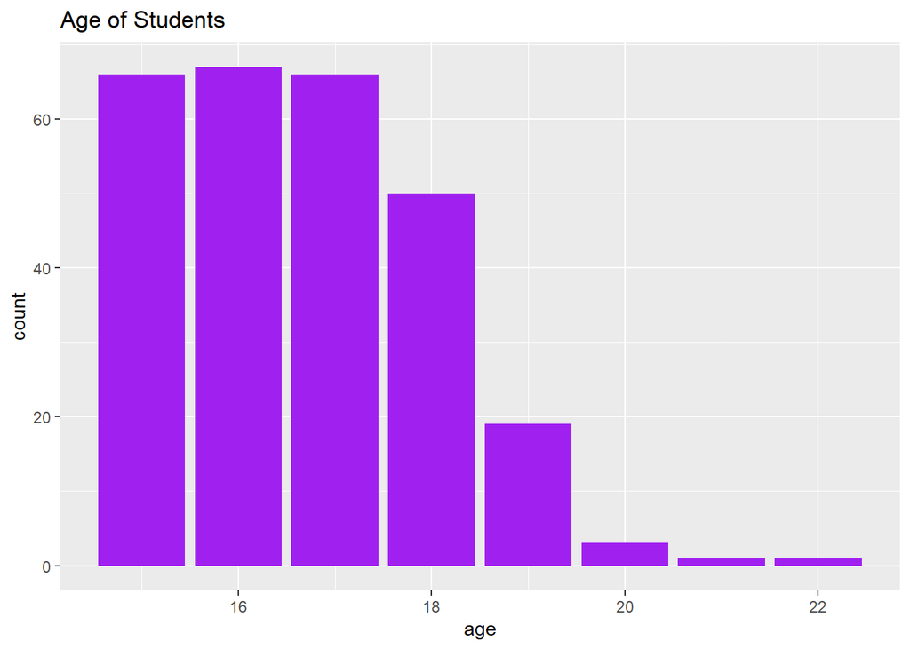

```r
mathscores %>%
  ggplot(aes(x = age)) +
  geom_bar(fill = "purple") +
  ggtitle('Age of Students')
```

The age of students ranges from 15 to 22 and the distribution is right skewed. The median age being 17 and mean being 16.66

```r
summary(mathscores$failures)
```

```
##    Min. 1st Qu.  Median    Mean 3rd Qu.    Max.
##   0.000   0.000   0.000   0.304   0.000   3.000
```

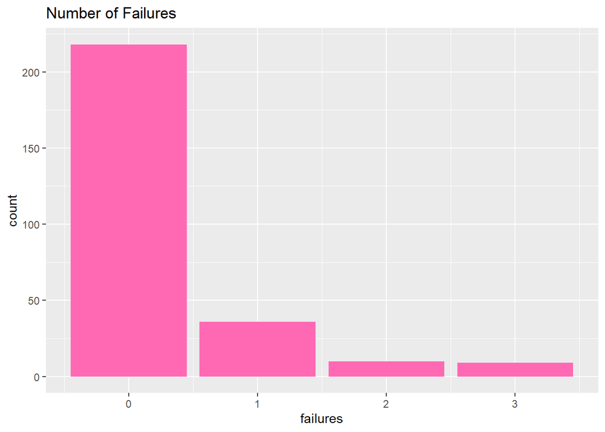

```r
mathscores %>%
  ggplot(aes(x = failures)) +
  geom_bar(fill = "hotpink") +
  ggtitle('Number of Failures')
```

The majority of students have 0 failures. Less than 50 students have one failure. Mean of 0.304, median of 0

```r
summary(mathscores$absences)
```

```
##    Min. 1st Qu.  Median    Mean 3rd Qu.    Max.
##   0.000   0.000   4.000   6.011   8.000  75.000
```

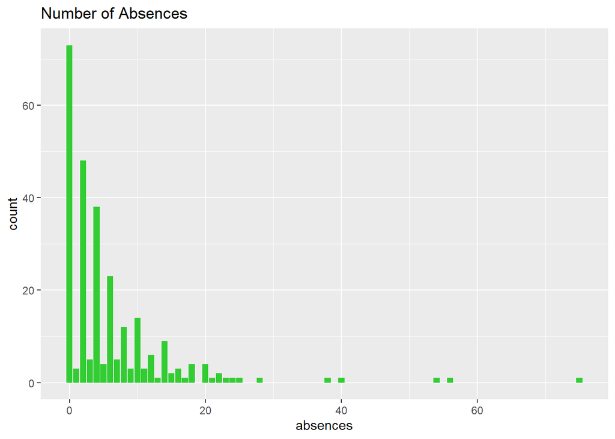

```r
mathscores %>%
  ggplot(aes(x = absences)) +
  geom_bar(fill = "limegreen") +
  ggtitle('Number of Absences')
```

This distribution of absences is positively skewed. There are several outliers with high numbers of absences but the most common number of absences is 0.

```r
table(mathscores$sex)
```

```
##
##   F   M
## 147 126
```

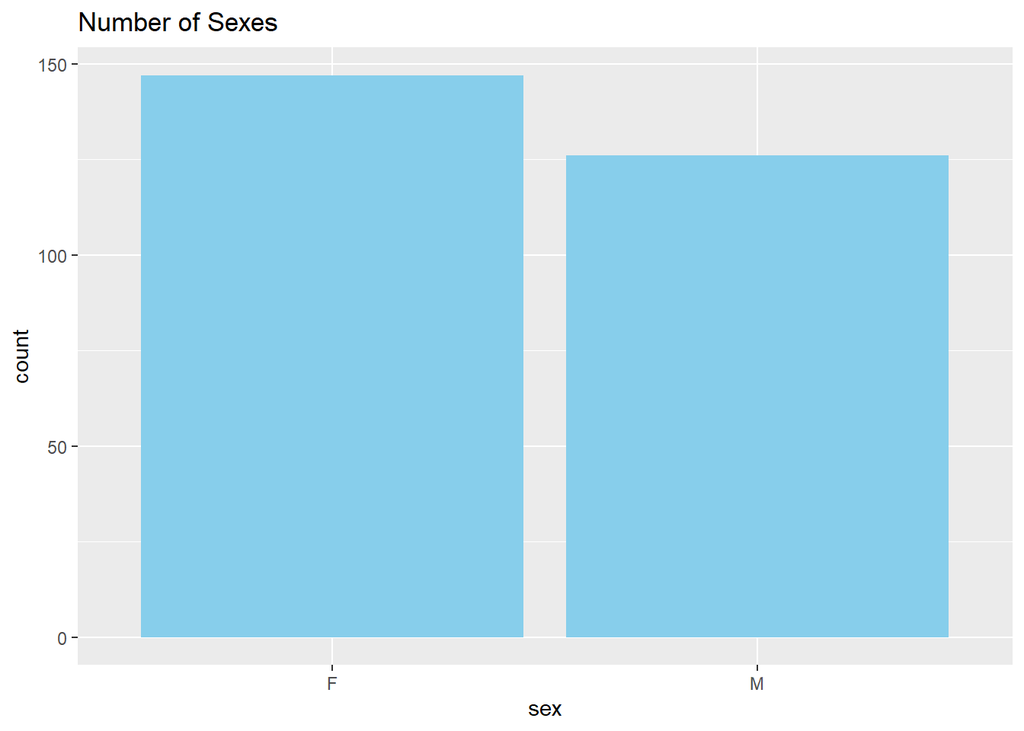

```r
mathscores %>%
  ggplot(aes(x = sex)) +
  geom_bar(fill = "skyblue") +
  ggtitle('Number of Sexes')
```

There are more female students in the data set than males. About 53.8% of the students are female.

```r
table(mathscores$address)
```

```
##
##   R   U
##  55 218
```

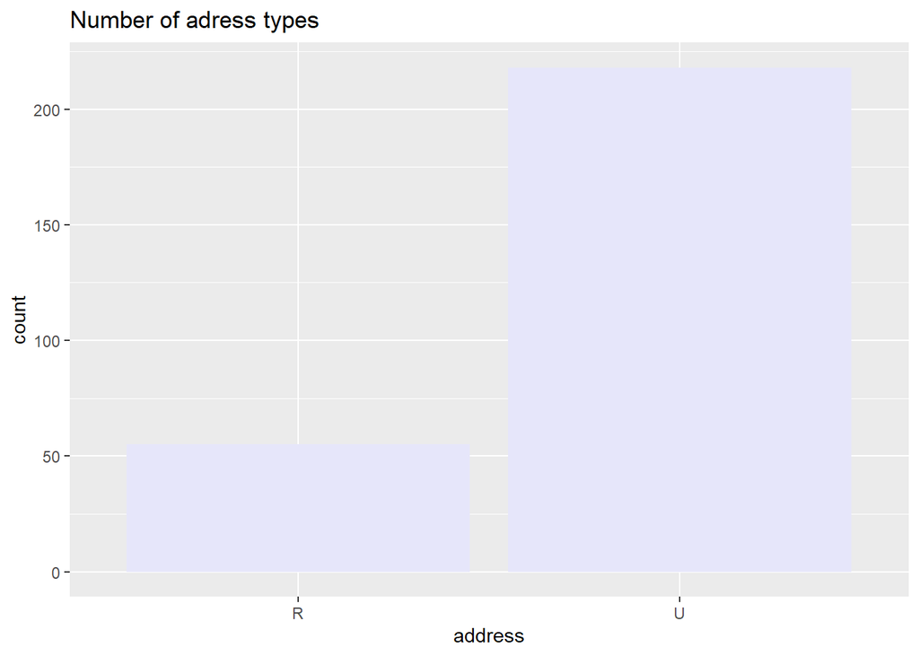

```r
mathscores %>%
  ggplot(aes(x = address)) +
  geom_bar(fill = "lavender") +
  ggtitle('Number of adress types')
```

There are more students with urban addresses than rural addresses. Only 20.1% of the students have rural addresses.

```r
table(mathscores$school)
```

```
##
##   A   B
## 242  31
```

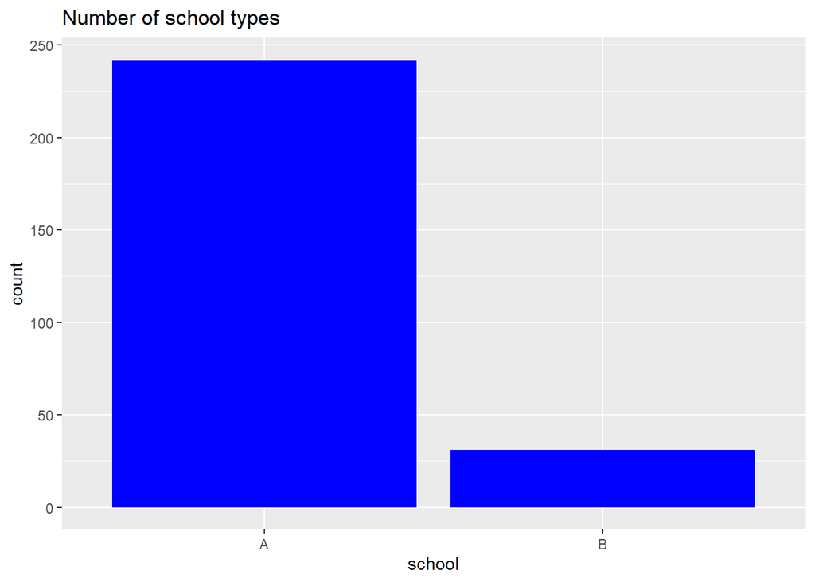

```r
mathscores %>%
  ggplot(aes(x = school)) +
  geom_bar(fill = "blue") +
  ggtitle('Number of school types')
```

The majority of students attend school A. Only about 11.4% of the students are from school B.

```r
table(mathscores$reason)
```

```
##
##     course       home      other reputation
##         97         76         26         74
```

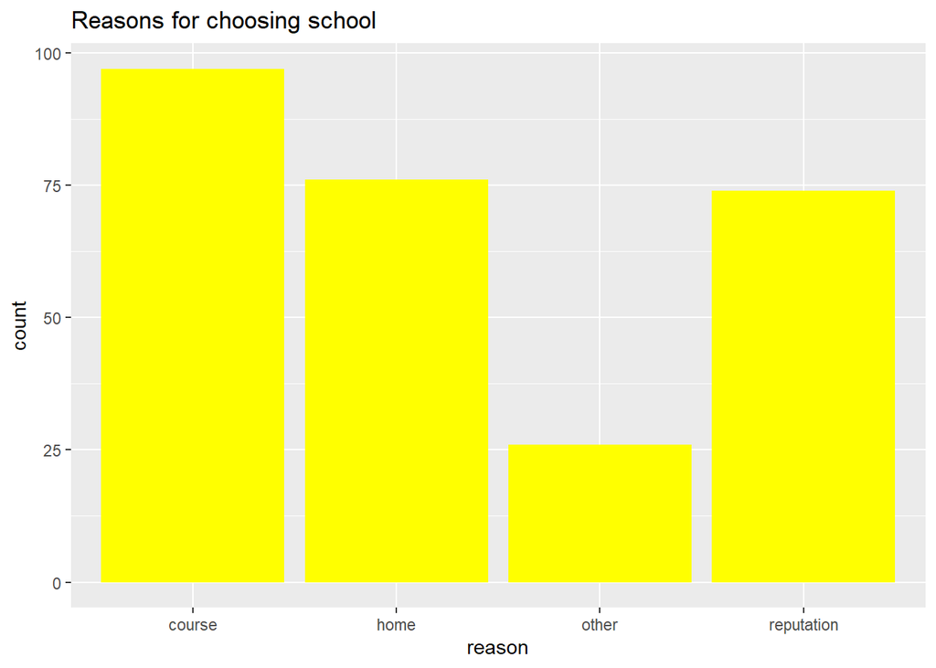

```r
mathscores %>%
  ggplot(aes(x = reason)) +
  geom_bar(fill = "yellow") +
  ggtitle('Reasons for choosing school')
```

The most popular reason for choosing a school was the courses offered and the reputation and it being close to home had similar results to eachother.

```r
table(mathscores$activities)
```

```
##
##  no yes
## 137 136
```

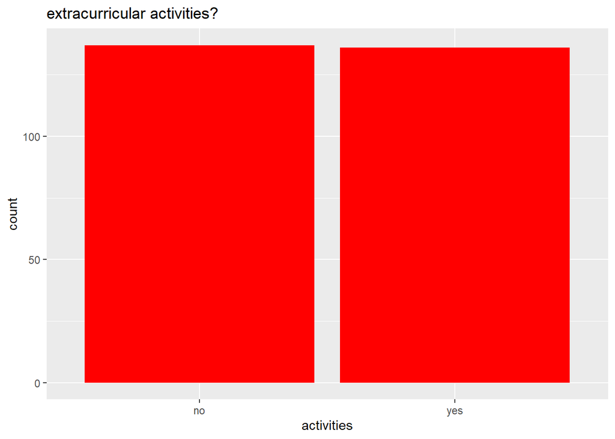

```r
mathscores %>%
  ggplot(aes(x = activities)) +
  geom_bar(fill = "red") +
  ggtitle('extracurricular activities?')
```

The number of students in activities is close to the number of students not in activities. There is one more student who is not in activities.

```r
table(mathscores$schoolsup)
```

```
##
##  no yes
## 232  41
```

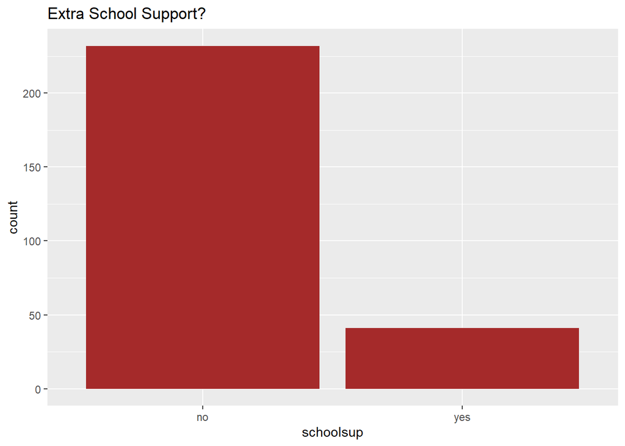

```r
mathscores %>%
  ggplot(aes(x = schoolsup)) +
  geom_bar(fill = "brown") +
  ggtitle('Extra School Support?')
```

The majority of students do not have addition educational support.

```r
table(mathscores$famsup)
```

```
##
##  no yes
##  95 178
```

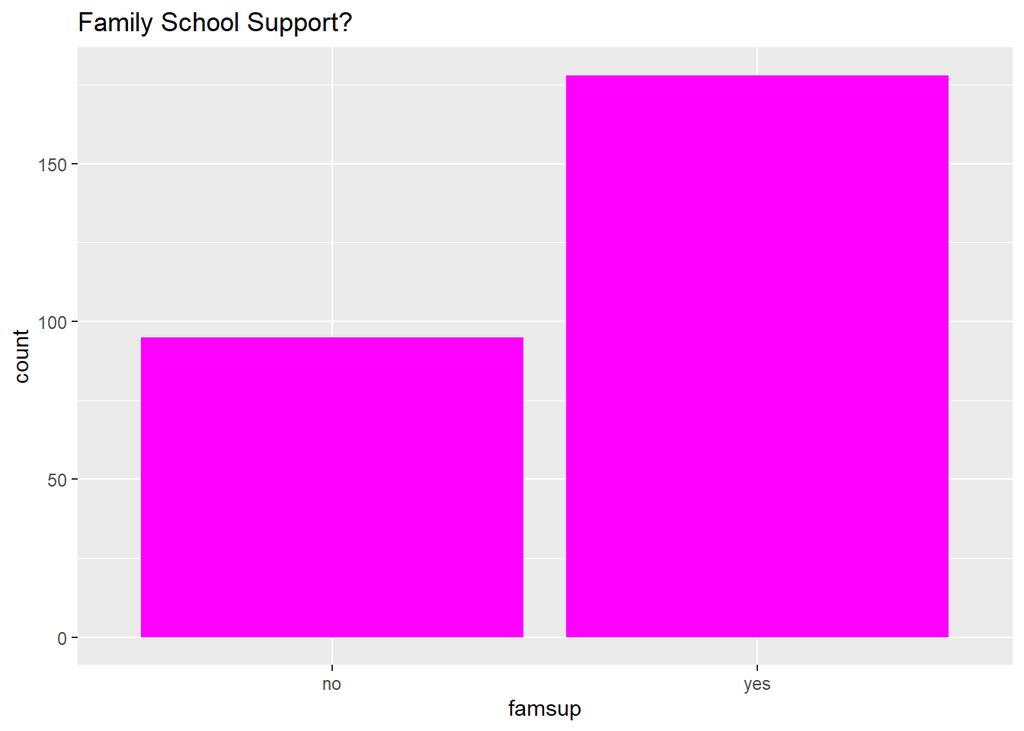

```r
mathscores %>%
  ggplot(aes(x = famsup)) +
  geom_bar(fill = "magenta") +
  ggtitle('Family School Support?')
```

Most students have family educational support 178 do and 95 don’t

```r
table(mathscores$paid)
```

```
##
##  no yes
## 147 126
```

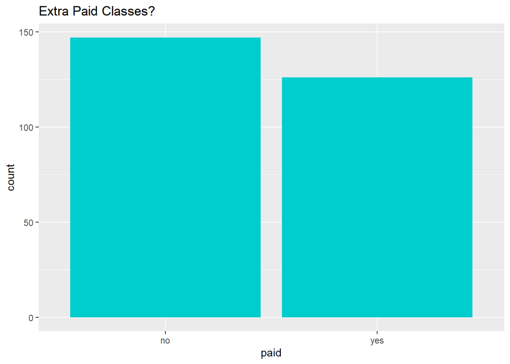

```r
mathscores %>%
  ggplot(aes(x = paid)) +
  geom_bar(fill = "cyan3") +
  ggtitle('Extra Paid Classes?')
```

A little less than half of the students have extra paid classes within the math subject area (126 yes, 147 no).

```r
table(mathscores$traveltime)
```

```
##
##   1   2   3   4
## 186  61  19   7
```

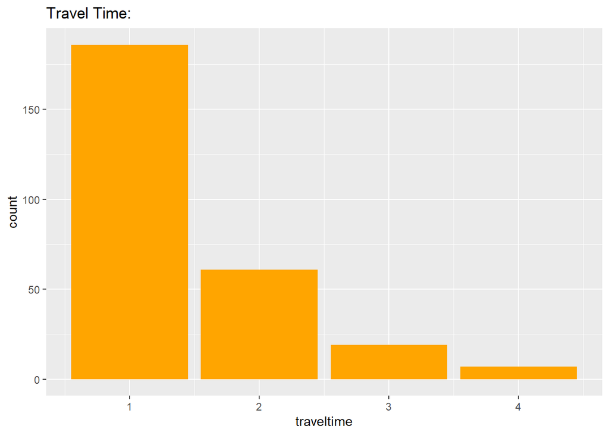

```r
mathscores %>%
  ggplot(aes(x = traveltime)) +
  geom_bar(fill = "orange") +
  ggtitle('Travel Time:')
```

There are 4 categories 1 = less than 15 mins, 2 = 15 to 30 minutes, 3 = 30 to 60 minutes and 4 = more than an hour. The majority of students take less than 15 minutes to get to class and only a few take more than an hour

```r
table(mathscores$studytime)
```

```
##
##   1   2   3   4
##  66 142  47  18
```

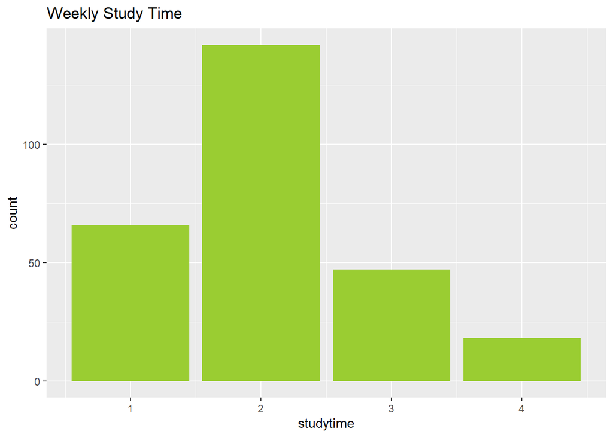

```r
mathscores %>%
  ggplot(aes(x = studytime)) +
  geom_bar(fill = "yellowgreen") +
  ggtitle('Weekly Study Time')
```

Weekly study time is also split into 4 categories: 1 = less than 2 hours, 2 = 2 to 5 hours, 3 = 5 to 10 hours, 4 = more than 10 hours. Most of the students study between 2 and 5 hours but alot also study for less than 2

```r
table(mathscores$freetime)
```

```
##
##   1   2   3   4   5
##  13  51 108  73  28
```

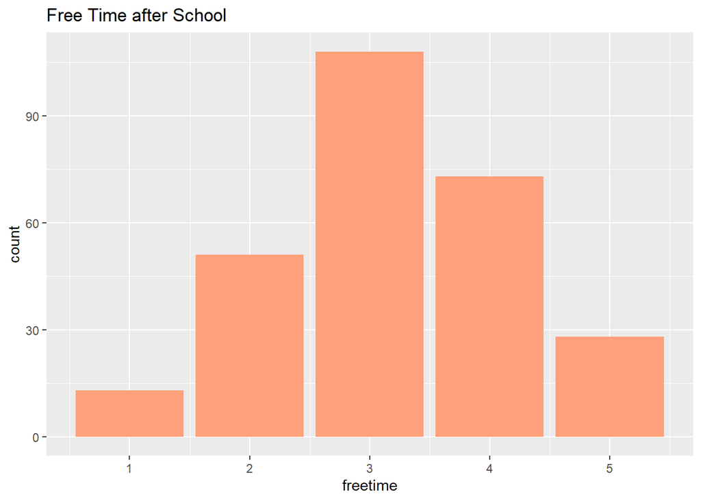

```r
mathscores %>%
  ggplot(aes(x = freetime)) +
  geom_bar(fill = "lightsalmon") +
  ggtitle('Free Time after School')
```

Lastly, free time after school is on a scale of 1 to 5 with 1 being very low amount of free time and 5 being very high amount of free time. About a third of students answered 3, meaning they have average free time after school. The least amount of people answered 1 and the most answered 3 this might not be accurate because we don’t know the numbers behind them.

In conclusion, there are both numerical and categorical variable that could help us predict a student’s success in math class and building the model to do this. We should start by building a tree with variables with the “important” variables. We would also make a full model with all the variables without over fitting. A nonparametirc model might be better using this data because some of the variables have non normal distributions or they have outliers.